# Homework 4

Connor Johnson

```r
library(ISLR)
library(dplyr)
library(MASS)
library(class)
library(bootstrap)
library(boot)
library(broom)
library(coin)
library(rcompanion)
```

## Problem 2

We can use the bootstrap approach to approximate the standard deviation. The bootstrap method works by re-sampling the observations from our data a large number of times. We can then use these samples to create a distribution of estimates for our prediction. Finding the standard deviation of this distribution will be an estimate for the standard deviation of out prediction.

## Problem 3

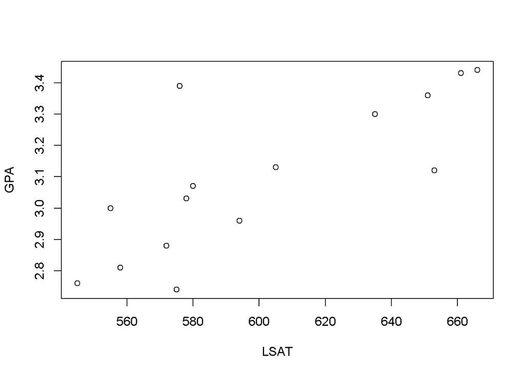

```r
library(bootstrap)
data(law)
plot(law)
```

```r
cor(law)
```

```
##           LSAT       GPA
## LSAT 1.0000000 0.7763745
## GPA  0.7763745 1.0000000
```

There does appear to be a strong positive linear relationship between LSAT score and GPA. The correlation between them is 0.7764

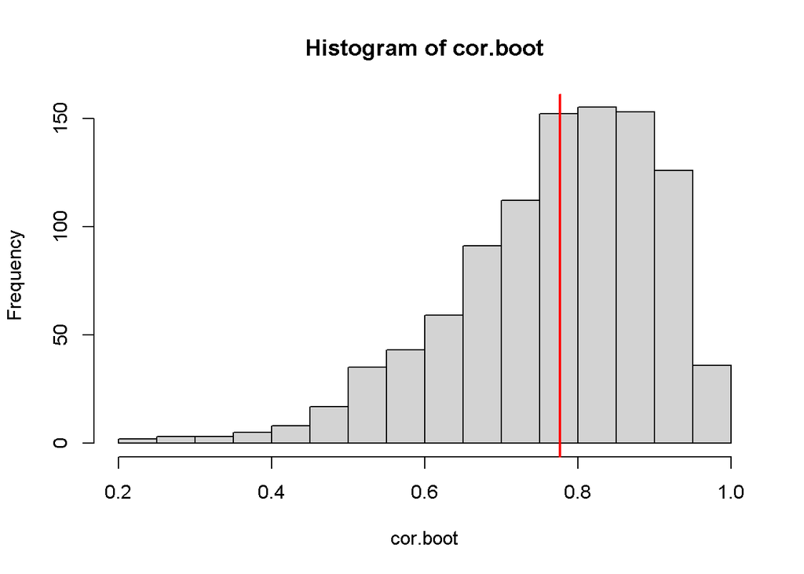

```r
nBoot <- 1000
data(law)
mean.boot <- rep(0,nBoot)
cor.boot = numeric(nBoot)
for (i in 1:nBoot) {
    xperm1 <- sample(1:nrow(law), size = nrow(law), replace=T)
    cor.boot[i] = cor(law[xperm1,1],law[xperm1,2])
}
hist(cor.boot, breaks=20)
set.seed(5)

cor0 = cor(law$LSAT,law$GPA)
abline(v=cor0, col="red", lwd=2)
```

```r
set.seed(22)
boot_corr <- function(data, resample_vector) {
    cor(data$x[resample_vector], data$y[resample_vector])
}
ds <- data.frame(y = law$LSAT, x = law$GPA)
boots <- boot(ds, boot_corr, R = 1000)
boot.ci(boots)
```

```
## BOOTSTRAP CONFIDENCE INTERVAL CALCULATIONS
## Based on 1000 bootstrap replicates
##
## CALL :
## boot.ci(boot.out = boots)
##
## Intervals :
## Level      Normal              Basic
## 95%   ( 0.5133,  1.0480 )   ( 0.5893,  1.1038 )
##
## Level     Percentile            BCa
## 95%   ( 0.4490,  0.9635 )   ( 0.2958,  0.9383 )
## Calculations and Intervals on Original Scale
## Some BCa intervals may be unstable
```

```r
hist(cor.boot, breaks=20)
print("Bias = -0.004255571")
```

```
## [1] "Bias = -0.004255571"
```

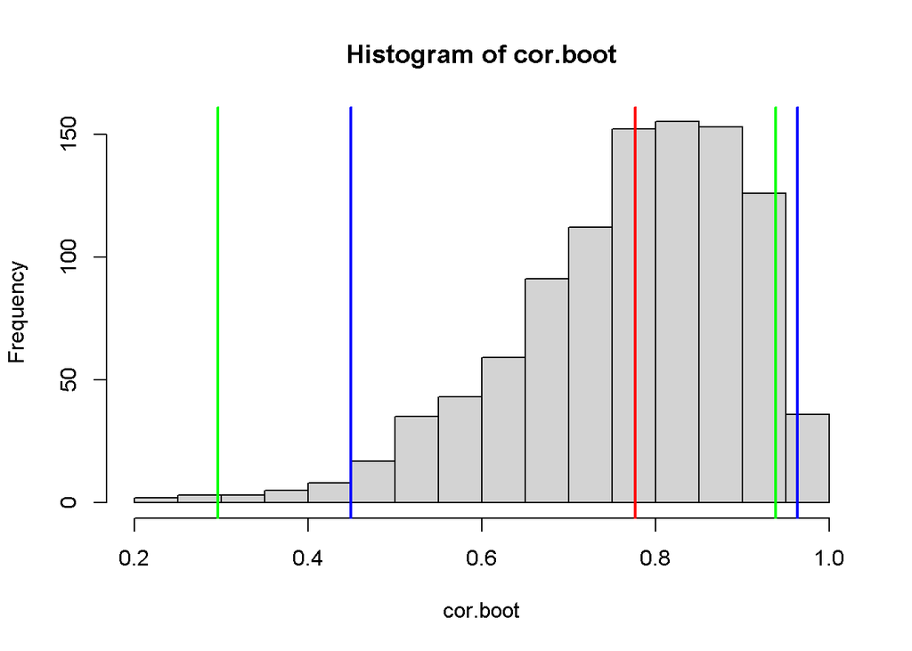

```r
abline(v=cor0, col="red", lwd=2)
abline(v=0.4490, col="blue", lwd=2)
abline(v=0.9635, col="blue", lwd=2)
abline(v=0.2958, col="green", lwd=2)
abline(v=0.9383, col="green", lwd=2)
```

Based on the confidence interval, we can’t reject the null hypothesis that the correlation is equal to 0.5 because 0.5 is within the confidence interval

Based on the bias corrected confidence interval, we cannot reject the null hypothesis that correlation is equal to 0.5 because 0.t is within the confidence interval.

```r
nperm <- 1000
law.perm <- numeric(nperm)
for (i in 1:nperm) {
  ind <- sample(nrow(law), replace = TRUE)
  law.perm[i] <- cor(law[ind, "LSAT"], law[ind, "GPA"])
}
mean(law.perm)
```

```
## [1] 0.7679349
```

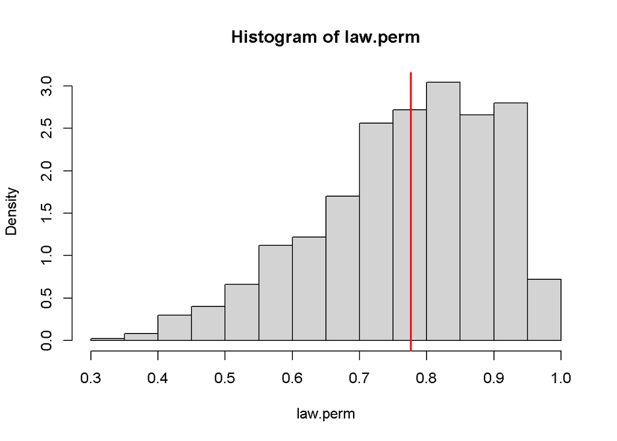

```r
hist(law.perm, freq = FALSE,breaks = 20)
abline(v=cor(law$LSAT,law$GPA),col='red',lwd=2)
```

```r
law.perm = sort(law.perm)
print(paste0("95% Confidence Interval: (",law.perm[25],", ",law.perm[975],")"))
```

```
## [1] "95% Confidence Interval: (0.467025634372559, 0.953952715586109)"
```

The confidence interval does not contain zero so we reject the null hypothesis that correlation is equal to zero.

## Problem 4

```r
X1 = runif(50)
X2 = runif(50)
epsilon = rnorm(50, 0, 0.25)
Y = X1 + X2 + epsilon
```

```r
#set.seed(1)
X1 = runif(50)
X2 = runif(50)
epsilon = rnorm(50, 0, 0.25)
Y = X1 + X2 + epsilon
reg = lm(Y~X1+X2)
X1_test = runif(30)
X2_test = runif(30)
epsilon_test = rnorm(30, 0, 0.25)
Y_test = X1_test + X2_test + epsilon_test

summary(reg)
```

```
##
## Call:
## lm(formula = Y ~ X1 + X2)
##
## Residuals:
##     Min      1Q  Median      3Q     Max
## -0.6436 -0.2155  0.0220  0.1792  0.5515
##
## Coefficients:
##             Estimate Std. Error t value Pr(>|t|)
## (Intercept) -0.15191    0.09174  -1.656    0.104
## X1           1.15754    0.13694   8.453 5.42e-11 ***
## X2           1.17819    0.13121   8.980 9.17e-12 ***
## ---
## Signif. codes:  0 '***' 0.001 '**' 0.01 '*' 0.05 '.' 0.1 ' ' 1
##
## Residual standard error: 0.2743 on 47 degrees of freedom
## Multiple R-squared:  0.8084, Adjusted R-squared:  0.8002
## F-statistic: 99.15 on 2 and 47 DF,  p-value: < 2.2e-16
```

```r
test = data.frame(X1_test,X2_test)
colnames(test) <- c("X1", "X2")
pred = predict(reg, test)
MSE0 = mean((pred-Y_test)^2)
```

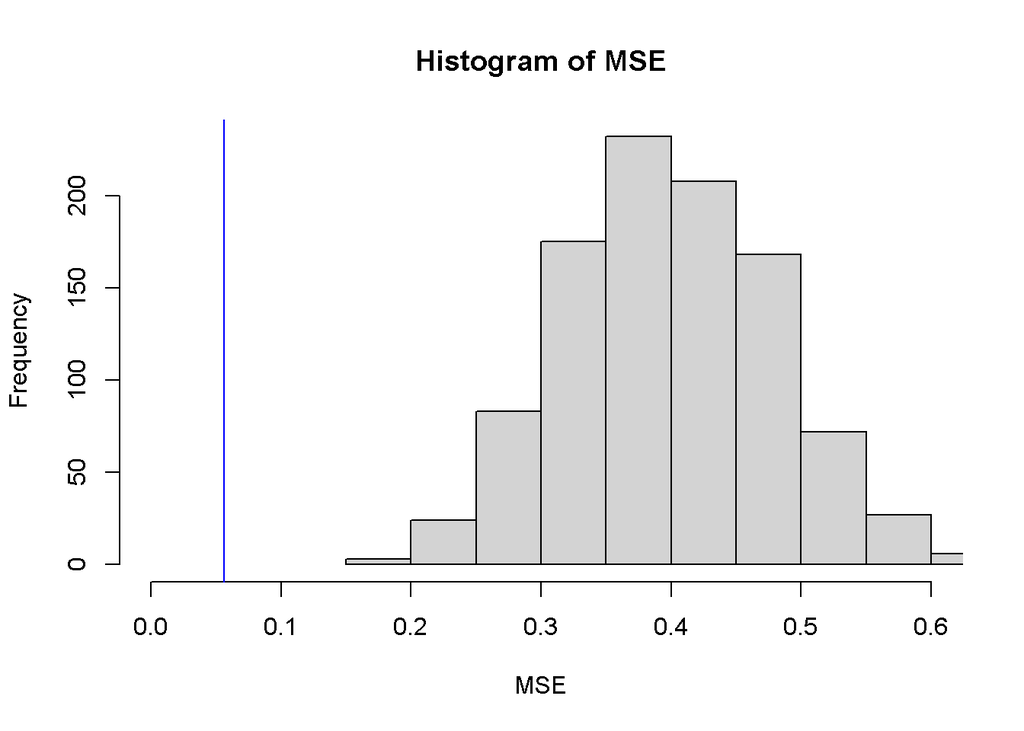

```r
perms = 1000
MSE = numeric(perms)
for(i in 1:perms){
  test$X1 = sample(test$X1)
  test$X2 = sample(test$X2)
  pred = predict(reg, test)
  MSE[i] = mean((pred-Y_test)^2)

}
hist(MSE, xlim=c(0,0.6))
abline(v=MSE0, col="blue")
```

```r
print(length(MSE[MSE < MSE0])/perms)
```

```
## [1] 0
```

We can reject the null hypothesis that $\beta_{1} = 0$ and $\beta_{2} = 0$ because the p-value is less than 0.05

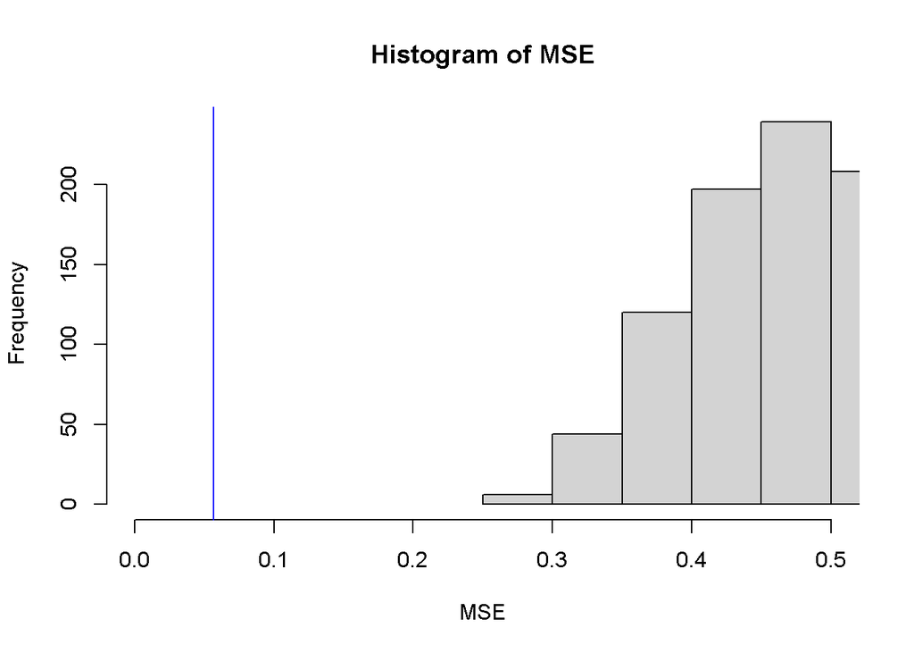

```r
perms = 1000
MSE = numeric(perms)
for(i in 1:perms){
  test$X2 = sample(test$X2)
  pred = predict(reg, test)
  MSE[i] = mean((pred-Y_test)^2)

}
hist(MSE, xlim=c(0,0.5))
abline(v=MSE0, col="blue")
```

```r
print(length(MSE[MSE < MSE0])/perms)
```

```
## [1] 0
```

```r
m <- matrix(runif(5000), ncol=10, nrow = 500)
Xs = data.frame(m)
colnames(Xs) <- c("X1","X2","X3","X4","X5","X6","X7","X8","X9","X10")
epsilon_2 = rnorm(500, 0, 0.25)
Y = Xs$X1+Xs$X2+Xs$X3+Xs$X4+Xs$X5+Xs$X6+Xs$X7+Xs$X8+Xs$X9+Xs$X10+epsilon_2

m <- matrix(runif(500), ncol=10, nrow = 50)
Xs_test = data.frame(m)
colnames(Xs) <- c("X1","X2","X3","X4","X5","X6","X7","X8","X9","X10")
epsilon_2_test = rnorm(50, 0, 0.25)

Y_test = Xs_test$X1+Xs_test$X2+Xs_test$X3+Xs_test$X4+Xs_test$X5+Xs_test$X6+Xs_test$X7+Xs_test$X8+Xs_test$X9+
  Xs_test$X10+epsilon_2_test

reg = lm(Y~X1+X2+X3+X4+X5+X6+X7+X8+X9+X10,data=Xs)

pred = predict(reg, Xs_test)
MSE0 = mean((pred-Y_test)^2)
```

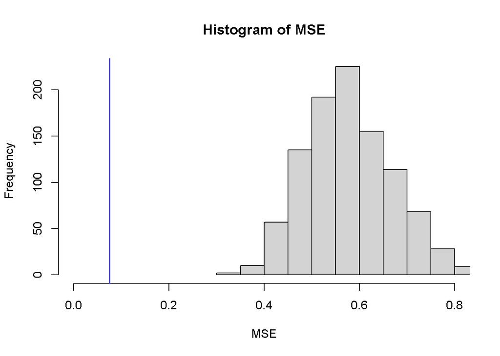

```r
X = c(Xs_test$X8, Xs_test$X9, Xs_test$X10)
perms = 1000
MSE = numeric(perms)
for(i in 1:perms){
  X <- sample(X)
  Xs_test$X8 = sample(Xs_test$X8)
  Xs_test$X9 = sample(Xs_test$X9)
  Xs_test$X10 = sample(Xs_test$X10)
  pred = predict(reg, Xs_test)
  MSE[i] = mean((pred-Y_test)^2)

}
hist(MSE, xlim=c(0,0.8))
abline(v=MSE0, col="blue")
```

```r
print(length(MSE[MSE < MSE0])/perms)
```

```
## [1] 0
```

We can reject the null hypothesis that $\beta_{8} = 0$, $\beta_{9} = 0$, and $\beta_{10} = 0$ because the p-value is less than 0.05

## Problem 5

We would perform a z-test on the two proportions of the group with hypotheses below

$$H_0: p_1=p_2$$
$$H_a: p_1 \gt p_2$$
$p_1$ is the placebo group and $p_2$ is the vaccinated group. The z-stat formula is
$$Z=\frac{p_1-p_2}{\sqrt{\frac{p q}{n_1} + \frac{p q}{n_2}}}$$
Plugging in our values, we get $Z=11.8347$ with $p \approx 0$. So, we can reject the null hypothesis which shows that the vaccine is effective.

We would expect that the number of positive cases in each group would be similar to each other.

We can use the difference in proportion between the two groups as our test statistic.

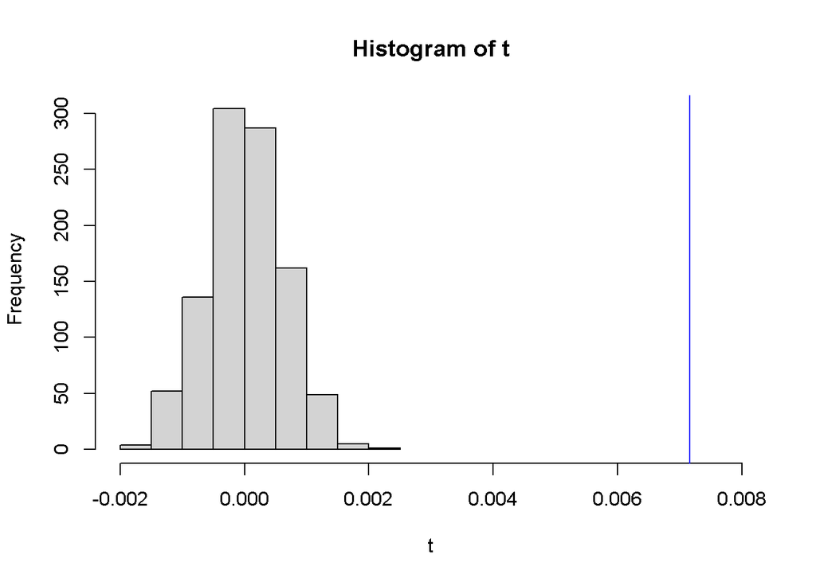

```r
vaccine = numeric(21500)
placebo = numeric(21500)
for (i in 1:8){
  vaccine[i] = 1
}
for (i in 1:162){
  placebo[i] = 1
}
t_star = mean(placebo)-mean(vaccine)
perms = 1000
t = numeric(perms)
for(i in 1:1000){
  X = numeric(43000)
  idx = sample(1:length(X), 170, replace=FALSE)
  X[idx] = 1
  vaccine = X[1:21500]
  placebo = X[21501:43000]
  t[i] = mean(placebo) - mean(vaccine)
}
hist(t, xlim=c(-0.002, 0.008))
abline(v=t_star, col="blue")
```

```r
print(length(t[t_star<t])/perms)
```

```
## [1] 0
```